# Bivariate Analysis

## Ucitavanje potrebnih biblioteka

```r
install.packages("DescTools")
```

```
Error in install.packages : Updating loaded packages
```

```r
library(tidyverse)
library(car)
library(FSA)
library(DescTools)
```

## Number.of.Dependents prema Education.Level varijabli

Proveravamo procentualnu zastupljenost po kategorijama

```r
tbl <- table(train$Education.Level, train$Number.of.Dependents)

prop_row <- prop.table(tbl, margin = 1) * 100
round(prop_row, 1)
```

```
                 0    1    2    3    4
  High School 20.2 19.7 19.6 20.4 20.2
  Bachelor's  19.9 19.8 19.8 20.3 20.3
  Master's    19.9 19.8 19.8 20.3 20.1
  PhD         20.0 19.6 19.8 20.3 20.3
```

Graficka reprezentacija varijabli

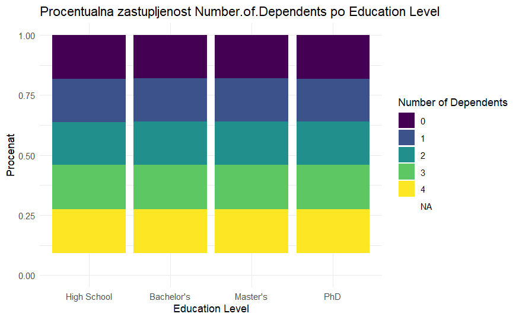

```r
ggplot(train, aes(x = Education.Level, fill = Number.of.Dependents)) +
  geom_bar(position = "fill") +
  theme_minimal() +
  labs(title = "Procentualna zastupljenost Number.of.Dependents po Education Level", x = "Education Level", fill = "Number of Dependents", y = "Procenat")
```

Chi_squared test radi statisticke provere znacajnosti izmedju kategorija:

```r
p_value <- chisq.test(table(train$Education.Level, train$Number.of.Dependents))$p.value

if (p_value > 0.05) {
  print("Ne postoji statistički značajna zavisnost između Education.Level i Number.of.Dependents.")
} else {
  print("Postoji statistički značajna zavisnost između Education.Level i Number.of.Dependents.")
}
```

```
[1] "Ne postoji statistički značajna zavisnost između Education.Level i Number.of.Dependents."
```

## Number.of.Dependents prema Occupation varijabli

Proveravamo procentualnu zastupljenost po kategorijama

```r
tbl <- table(train$Occupation, train$Number.of.Dependents)

prop_row <- prop.table(tbl, margin = 1) * 100
round(prop_row, 1)
```

```
                   0    1    2    3    4
  Employed      20.0 19.7 19.8 20.3 20.2
  Self-Employed 20.0 19.8 19.7 20.4 20.0
  Unemployed    20.0 19.8 19.7 20.3 20.2
```

Graficka reprezentacija varijabli

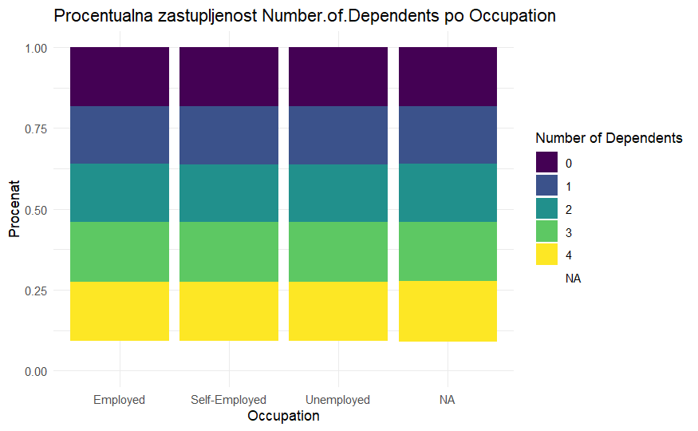

```r
ggplot(train, aes(x = Occupation, fill = Number.of.Dependents)) +
  geom_bar(position = "fill") +
  theme_minimal() +
  labs(title = "Procentualna zastupljenost Number.of.Dependents po Occupation", x = "Occupation", fill = "Number of Dependents",y = "Procenat")
```

Chi_squared test radi statisticke provere znacajnosti izmedju kategorija:

```r
p_value <- chisq.test(table(train$Education.Level, train$Number.of.Dependents))$p.value

if (p_value > 0.05) {
  print("Ne postoji statistički značajna zavisnost između Occupation i Number.of.Dependents.")
} else {
  print("Postoji statistički značajna zavisnost između Occupation i Number.of.Dependents.")
}
```

[output not shown]

## Number.of.Dependents prema Property.Type varijabli

Proveravamo procentualnu zastupljenost po kategorijama

```r
tbl <- table(train$Property.Type, train$Number.of.Dependents)

prop_row <- prop.table(tbl, margin = 1) * 100
round(prop_row, 1)
```

```
               0    1    2    3    4
  Apartment 20.0 19.8 19.8 20.4 20.1
  Condo     20.2 19.7 19.7 20.2 20.2
  House     19.9 19.7 19.8 20.3 20.3
```

Graficka reprezentacija varijabli

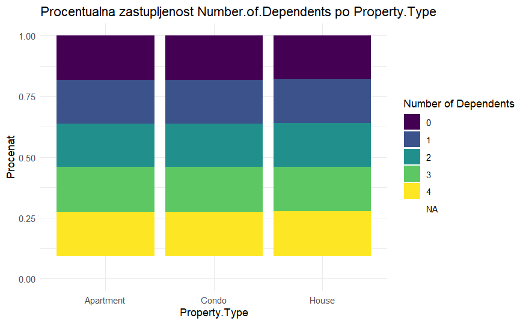

```r
ggplot(train, aes(x = Property.Type, fill = Number.of.Dependents)) +
  geom_bar(position = "fill") +
  theme_minimal() +
  labs(title = "Procentualna zastupljenost Number.of.Dependents po Property.Type", x = "Property.Type", fill = "Number of Dependents",y = "Procenat")
```

Chi_squared test radi statisticke provere znacajnosti izmedju kategorija:

```r
p_value <- chisq.test(table(train$Property.Type, train$Number.of.Dependents))$p.value

if (p_value > 0.05) {
  print("Ne postoji statistički značajna zavisnost između Property.Type i Number.of.Dependents.")
} else {
  print("Postoji statistički značajna zavisnost između Property.Type i Number.of.Dependents.")
}
```

```
[1] "Postoji statistički značajna zavisnost između Property.Type i Number.of.Dependents."
```

Proveravamo jacinu veze pomocu Cramer V

```r
CramerV(table(train$Number.of.Dependents, train$Property.Type))
```

```
[1] 0.003223866
```

Iako Chi_squared test ukazuje na statisticku zavisnost izmedju Number.of.Dependents i Property.Type, jacina te veze je veoma slaba i raspodela po kategorijama je gotovo identicna, tako da se veza moze smatrati zanemarljivom.

## Number.of.Dependents prema Previous.Claims varijabli

Posto su grupe koje imaju 7-9 zahteva veoma male, grupisacemo ih u jednu kategoriju “7+” radi testiranja.

```r
train$PreviousClaimsGrouped <- as.character(train$Previous.Claims)
train$PreviousClaimsGrouped[train$PreviousClaimsGrouped %in% c("7","8","9")] <- "7+"
train$PreviousClaimsGrouped <- factor(train$PreviousClaimsGrouped,
                                      levels = c("0","1","2","3","4","5","6","7+"))

table(train$PreviousClaimsGrouped, useNA="ifany")
```

```
     0      1      2      3      4      5      6     7+   <NA>
305433 300811 167661  49011  10668   2018    302     67 364029
```

Proveravamo procentualnu zastupljenost po kategorijama

```r
tbl <- table(train$PreviousClaimsGrouped, train$Number.of.Dependents)

prop_row <- prop.table(tbl, margin = 1) * 100
round(prop_row, 1)
```

```
        0    1    2    3    4
  0  19.5 20.0 19.9 20.3 20.3
  1  20.1 19.5 19.7 20.4 20.3
  2  20.1 19.8 19.4 20.3 20.4
  3  20.4 19.7 19.7 20.4 19.8
  4  20.7 20.2 18.8 19.9 20.4
  5  21.2 18.5 18.9 18.6 22.7
  6  21.0 20.2 21.0 18.3 19.5
  7+ 22.2 22.2 19.0 17.5 19.0
```

Graficka reprezentacija varijabli

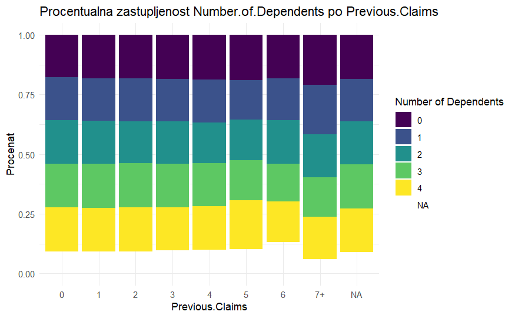

```r
ggplot(train, aes(x = PreviousClaimsGrouped, fill = Number.of.Dependents)) +
  geom_bar(position = "fill") +
  theme_minimal() +
  labs(title = "Procentualna zastupljenost Number.of.Dependents po Previous.Claims", x = "Previous.Claims", fill = "Number of Dependents",y = "Procenat")
```

Chi_squared test radi statisticke provere znacajnosti izmedju kategorija:

```r
p_value <- chisq.test(table(train$PreviousClaimsGrouped, train$Number.of.Dependents))$p.value

if (p_value > 0.05) {
  print("Ne postoji statistički značajna zavisnost između Previous.Claims i Number.of.Dependents.")
} else {
  print("Postoji statistički značajna zavisnost između Previous.Claims i Number.of.Dependents.")
}
```

```
[1] "Postoji statistički značajna zavisnost između Previous.Claims i Number.of.Dependents."
```

Proveravamo jacinu veze pomocu Cramer V

```r
CramerV(table(train$Number.of.Dependents, train$PreviousClaimsGrouped))
```

```
[1] 0.005575865
```

Odbacujemo kolonu PreviousClaimsGrouped

```r
train <- train %>%
  select(-PreviousClaimsGrouped)
```

Iako Chi_squared test ukazuje na statisticku zavisnost izmedju Number.of.Dependents i Previous.Claims, jacina te veze je veoma slaba i raspodela po kategorijama je gotovo identicna, tako da se veza moze smatrati zanemarljivom.

## Insurance.Duration prema Occupation varijabli

Proveravamo procentualnu zastupljenost po kategorijama

```r
tbl <- table(train$Occupation, train$Insurance.Duration)

prop_row <- prop.table(tbl, margin = 1) * 100
round(prop_row, 1)
```

```
                   1    2    3    4    5    6    7    8    9
  Employed      11.3 11.0 11.0 10.9 11.0 11.0 11.1 11.1 11.5
  Self-Employed 11.2 11.0 11.0 10.9 11.1 11.1 11.1 11.1 11.5
  Unemployed    11.2 10.8 10.9 11.1 11.0 11.0 11.1 11.3 11.5
```

Graficka reprezentacija varijabli

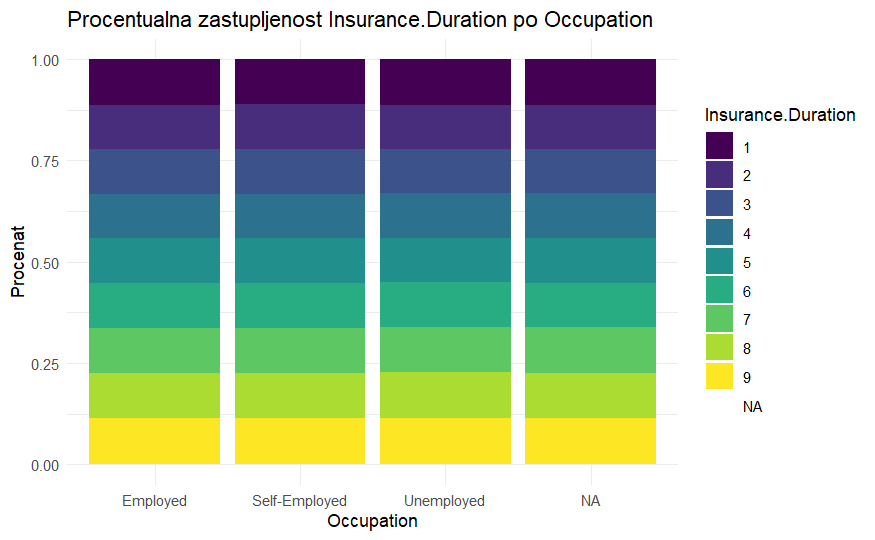

```r
ggplot(train, aes(x = Occupation, fill = Insurance.Duration)) +
  geom_bar(position = "fill") +
  theme_minimal() +
  labs(title = "Procentualna zastupljenost Insurance.Duration po Occupation", x = "Occupation", fill = "Insurance.Duration",y = "Procenat")
```

Chi_squared test radi statisticke provere znacajnosti izmedju kategorija:

```r
p_value <- chisq.test(table(train$Occupation, train$Insurance.Duration))$p.value

if (p_value > 0.05) {
  print("Ne postoji statistički značajna zavisnost između Occupation i Insurance.Duration.")
} else {
  print("Postoji statistički značajna zavisnost između Occupation i Insurance.Duration.")
}
```

```
[1] "Postoji statistički značajna zavisnost između Occupation i Insurance.Duration."
```

Proveravamo jacinu veze pomocu Cramer V

```r
CramerV(table(train$Occupation, train$Insurance.Duration))
```

```
[1] 0.00395789
```

Iako Chi_squared test ukazuje na statisticku zavisnost izmedju Occupation i Insurance.Duration, jacina te veze je veoma mala i raspodela po kategorijama je gotovo identicna, tako da se veza moze smatrati zanemarljivom.

## Insurance.Duration prema Property.Type varijabli

Proveravamo procentualnu zastupljenost po kategorijama

```r
tbl <- table(train$Property.Type, train$Insurance.Duration)

prop_row <- prop.table(tbl, margin = 1) * 100
round(prop_row, 1)
```

```
               1    2    3    4    5    6    7    8    9
  Apartment 11.2 10.9 11.0 11.0 11.1 11.0 11.2 11.2 11.5
  Condo     11.2 11.0 11.0 11.0 11.1 11.0 11.2 11.1 11.4
  House     11.3 10.8 11.1 11.0 11.0 11.0 11.1 11.2 11.5
```

Graficka reprezentacija varijabli

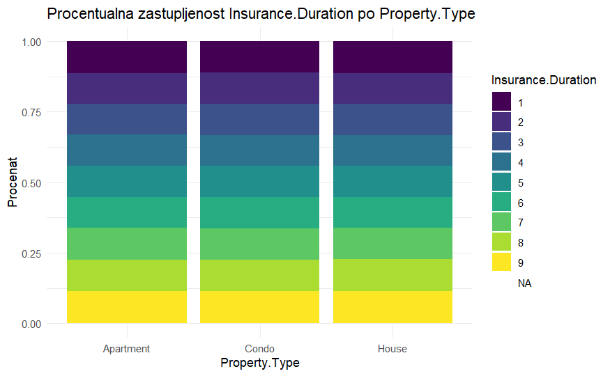

```r
ggplot(train, aes(x = Property.Type, fill = Insurance.Duration)) +
  geom_bar(position = "fill") +
  theme_minimal() +
  labs(title = "Procentualna zastupljenost Insurance.Duration po Property.Type", x = "Property.Type", fill = "Insurance.Duration",y = "Procenat")
```

Chi_squared test radi statisticke provere znacajnosti izmedju kategorija:

```r
p_value <- chisq.test(table(train$Property.Type, train$Insurance.Duration))$p.value

if (p_value > 0.05) {
  print("Ne postoji statistički značajna zavisnost između Property.Type i Insurance.Duration.")
} else {
  print("Postoji statistički značajna zavisnost između Property.Type i Insurance.Duration.")
}
```

```
[1] "Postoji statistički značajna zavisnost između Property.Type i Insurance.Duration."
```

Proveravamo jacinu veze pomocu Cramer V

```r
CramerV(table(train$Insurance.Duration, train$Property.Type))
```

```
[1] 0.003394748
```

Iako Chi_squared test ukazuje na statisticku zavisnost izmedju Insurance.Duration i Property.Type, jacina te veze je veoma slaba i raspodela po kategorijama je gotovo identicna, tako da se veza moze smatrati zanemarljivom.

## Previous.Claims prema Location varijabli

Posto su grupe koje imaju 7-9 zahteva veoma male, grupisacemo ih u jednu kategoriju “7+” radi testiranja.

```r
train$PreviousClaimsGrouped <- as.character(train$Previous.Claims)
train$PreviousClaimsGrouped[train$PreviousClaimsGrouped %in% c("7","8","9")] <- "7+"
train$PreviousClaimsGrouped <- factor(train$PreviousClaimsGrouped,
                                      levels = c("0","1","2","3","4","5","6","7+"))

table(train$PreviousClaimsGrouped, useNA="ifany")
```

```
     0      1      2      3      4      5      6     7+   <NA>
305433 300811 167661  49011  10668   2018    302     67 364029
```

Proveravamo procentualnu zastupljenost po kategorijama

```r
tbl <- table(train$Location, train$PreviousClaimsGrouped)

prop_row <- prop.table(tbl, margin = 1) * 100
round(prop_row, 1)
```

```
              0    1    2    3    4    5    6   7+
  Rural    36.6 36.0 20.0  5.9  1.3  0.3  0.0  0.0
  Suburban 36.4 36.1 20.0  5.9  1.3  0.2  0.0  0.0
  Urban    36.7 35.8 20.1  5.8  1.3  0.2  0.0  0.0
```

Graficka reprezentacija varijabli

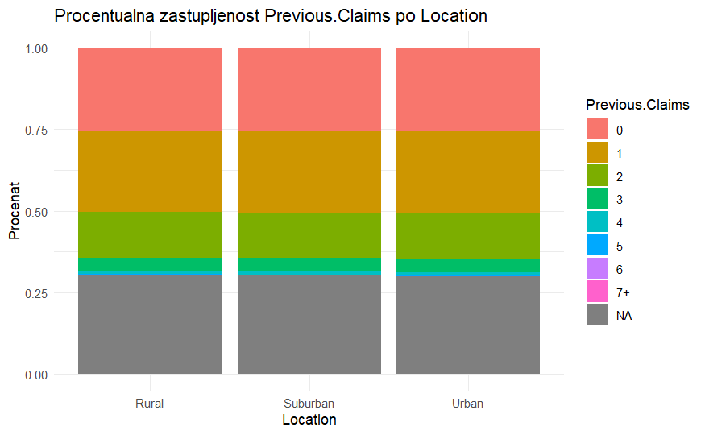

```r
ggplot(train, aes(x = Location, fill = PreviousClaimsGrouped)) +
  geom_bar(position = "fill") +
  theme_minimal() +
  labs(title = "Procentualna zastupljenost Previous.Claims po Location", x = "Location", fill = "Previous.Claims",y = "Procenat")
```

Chi_squared test radi statisticke provere znacajnosti izmedju kategorija:

```r
p_value <- chisq.test(table(train$PreviousClaimsGrouped, train$Location))$p.value

if (p_value > 0.05) {
  print("Ne postoji statistički značajna zavisnost između Previous.Claims i Location.")
} else {
  print("Postoji statistički značajna zavisnost između Previous.Claims i Location.")
}
```

```
[1] "Ne postoji statistički značajna zavisnost između Previous.Claims i Location."
```

Odbacujemo kolonu PreviousClaimsGrouped

```r
train <- train %>%
  select(-PreviousClaimsGrouped)
```

## Previous.Claims prema Customer.Feedback varijabli

Posto su grupe koje imaju 7-9 zahteva veoma male, grupisacemo ih u jednu kategoriju “7+” radi testiranja.

```r
train$PreviousClaimsGrouped <- as.character(train$Previous.Claims)
train$PreviousClaimsGrouped[train$PreviousClaimsGrouped %in% c("7","8","9")] <- "7+"
train$PreviousClaimsGrouped <- factor(train$PreviousClaimsGrouped,
                                      levels = c("0","1","2","3","4","5","6","7+"))

table(train$PreviousClaimsGrouped, useNA="ifany")
```

```
     0      1      2      3      4      5      6     7+   <NA>
305433 300811 167661  49011  10668   2018    302     67 364029
```

Proveravamo procentualnu zastupljenost po kategorijama

```r
tbl <- table(train$Customer.Feedback, train$PreviousClaimsGrouped)

prop_row <- prop.table(tbl, margin = 1) * 100
round(prop_row, 1)
```

```
             0    1    2    3    4    5    6   7+
  Poor    36.7 36.1 20.0  5.7  1.3  0.2  0.0  0.0
  Average 36.5 36.1 20.1  5.8  1.3  0.2  0.0  0.0
  Good    36.7 35.9 19.9  5.9  1.3  0.3  0.0  0.0
```

Graficka reprezentacija varijabli

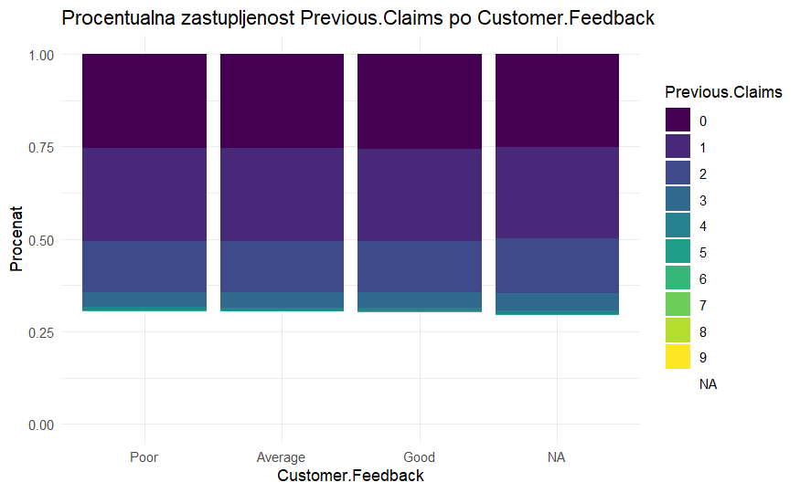

```r
ggplot(train, aes(x = Customer.Feedback, fill = Previous.Claims)) +
  geom_bar(position = "fill") +
  theme_minimal() +
  labs(title = "Procentualna zastupljenost Previous.Claims po Customer.Feedback", x = "Customer.Feedback", fill = "Previous.Claims",y = "Procenat")
```

Chi_squared test radi statisticke provere znacajnosti izmedju kategorija:

```r
p_value <- chisq.test(table(train$PreviousClaimsGrouped, train$Customer.Feedback))$p.value

if (p_value > 0.05) {
  print("Ne postoji statistički značajna zavisnost između Previous.Claims i Customer.Feedback")
} else {
  print("Postoji statistički značajna zavisnost između Previous.Claims i Customer.Feedback")
}
```

```
[1] "Postoji statistički značajna zavisnost između Previous.Claims i Customer.Feedback"
```

Proveravamo jacinu veze pomocu Cramer V

```r
CramerV(table(train$PreviousClaimsGrouped, train$Customer.Feedback))
```

```
[1] 0.004492751
```

Odbacujemo kolonu PreviousClaimsGrouped

```r
train <- train %>%
  select(-PreviousClaimsGrouped)
```

Iako Chi_squared test ukazuje na statisticku zavisnost izmedju Previous.Claims i Customer.Feedback, jacina te veze je veoma slaba i raspodela po kategorijama je gotovo identicna (mada postoji za 5-7+ zahteva mala razlika u procentima), tako da se veza moze smatrati zanemarljivom.

## Occupation prema Education.Level varijabli

Proveravamo procentualnu zastupljenost po kategorijama

```r
tbl <- table(train$Education.Level, train$Occupation)

prop_row <- prop.table(tbl, margin = 1) * 100
round(prop_row, 1)
```

```
              Employed Self-Employed Unemployed
  High School     33.5          33.6       32.8
  Bachelor's      33.8          33.5       32.7
  Master's        33.5          33.6       33.0
  PhD             33.6          33.6       32.8
```

Graficka reprezentacija varijabli

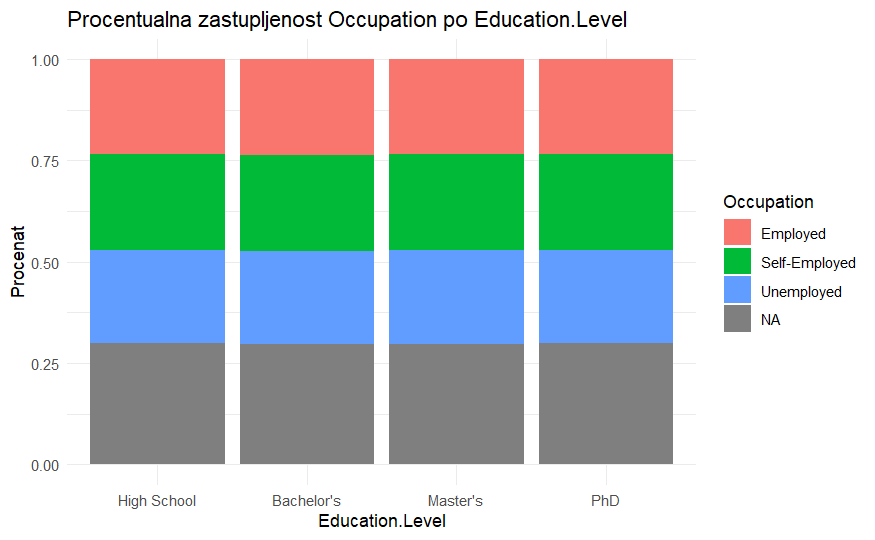

```r
ggplot(train, aes(x = Education.Level, fill = Occupation)) +
  geom_bar(position = "fill") +
  theme_minimal() +
  labs(title = "Procentualna zastupljenost Occupation po Education.Level", x = "Education.Level", fill = "Occupation",y = "Procenat")
```

Chi_squared test radi statisticke provere znacajnosti izmedju kategorija:

```r
p_value <- chisq.test(table(train$Occupation, train$Education.Level))$p.value

if (p_value > 0.05) {
  print("Ne postoji statistički značajna zavisnost između Occupation i Education.Level.")
} else {
  print("Postoji statistički značajna zavisnost između Occupation i Education.Level.")
}
```

```
[1] "Ne postoji statistički značajna zavisnost između Occupation i Education.Level."
```

## Occupation prema Location varijabli

Proveravamo procentualnu zastupljenost po kategorijama

```r
tbl <- table(train$Location, train$Occupation)

prop_row <- prop.table(tbl, margin = 1) * 100
round(prop_row, 1)
```

```
           Employed Self-Employed Unemployed
  Rural        33.7          33.5       32.8
  Suburban     33.5          33.6       32.9
  Urban        33.6          33.6       32.8
```

Graficka reprezentacija varijabli

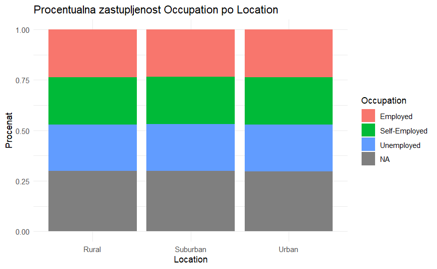

```r
ggplot(train, aes(x = Location, fill = Occupation)) +
  geom_bar(position = "fill") +
  theme_minimal() +
  labs(title = "Procentualna zastupljenost Occupation po Location", x = "Location", fill = "Occupation",y = "Procenat")
```

Chi_squared test radi statisticke provere znacajnosti izmedju kategorija:

```r
p_value <- chisq.test(table(train$Occupation, train$Location))$p.value

if (p_value > 0.05) {
  print("Ne postoji statistički značajna zavisnost između Occupation i Location.")
} else {
  print("Postoji statistički značajna zavisnost između Occupation i Location.")
}
```

```
[1] "Ne postoji statistički značajna zavisnost između Occupation i Location."
```

## Policy.Type prema Property.Type varijabli

Proveravamo procentualnu zastupljenost po kategorijama

```r
tbl <- table(train$Policy.Type, train$Property.Type)

prop_row <- prop.table(tbl, margin = 1) * 100
round(prop_row, 1)
```

```
                Apartment Condo House
  Basic              33.3  33.3  33.4
  Comprehensive      33.4  33.2  33.4
  Premium            33.3  33.5  33.2
```

Graficka reprezentacija varijabli

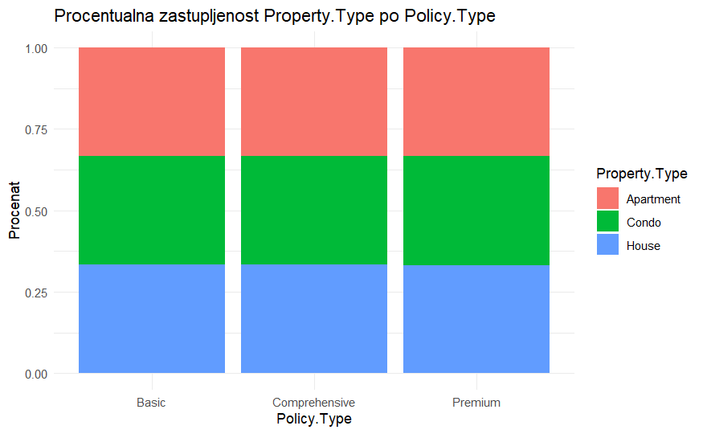

```r
ggplot(train, aes(x = Policy.Type, fill = Property.Type)) +
  geom_bar(position = "fill") +
  theme_minimal() +
  labs(title = "Procentualna zastupljenost Property.Type po Policy.Type", x = "Policy.Type", fill = "Property.Type",y = "Procenat")
```

Chi_squared test radi statisticke provere znacajnosti izmedju kategorija:

```r
p_value <- chisq.test(table(train$Policy.Type, train$Property.Type))$p.value

if (p_value > 0.05) {
  print("Ne postoji statistički značajna zavisnost između Policy.Type i Property.Type.")
} else {
  print("Postoji statistički značajna zavisnost između Policy.Type i Property.Type.")
}
```

```
[1] "Ne postoji statistički značajna zavisnost između Policy.Type i Property.Type."
```

## Policy.Type prema Location varijabli

Proveravamo procentualnu zastupljenost po kategorijama

```r
tbl <- table(train$Policy.Type, train$Location)

prop_row <- prop.table(tbl, margin = 1) * 100
round(prop_row, 1)
```

```
                Rural Suburban Urban
  Basic          33.4     33.5  33.1
  Comprehensive  33.5     33.3  33.2
  Premium        33.3     33.6  33.1
```

Graficka reprezentacija varijabli

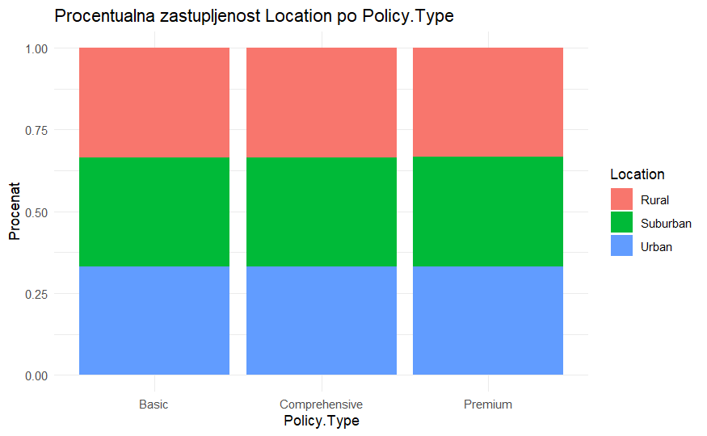

```r
ggplot(train, aes(x = Policy.Type, fill = Location)) +
  geom_bar(position = "fill") +
  theme_minimal() +
  labs(title = "Procentualna zastupljenost Location po Policy.Type", x = "Policy.Type", fill = "Location",y = "Procenat")
```

Chi_squared test radi statisticke provere znacajnosti izmedju kategorija:

```r
p_value <- chisq.test(table(train$Policy.Type, train$Location))$p.value

if (p_value > 0.05) {
  print("Ne postoji statistički značajna zavisnost između Policy.Type i Location.")
} else {
  print("Postoji statistički značajna zavisnost između Policy.Type i Location.")
}
```

```
[1] "Ne postoji statistički značajna zavisnost između Policy.Type i Location."
```

## Zakljucak:

- Iako Chi_squared test ukazuje na statisticku zavisnost izmedju pojedinih varijabli, daljom analizom je utvrdjeno da je ova razlika minimalna i prakticno neprimenljiva.